# A Time Series Analysis on Nesting Habits of Loggerhead Turtles

Author

Rachel Hudson

# 1 Introduction

## 1.1 Problem Definition

The goal of this project is to use Time Series Analysis to evaluate the seasonality of Loggerhead Turtle nesting habits, specifically, how predictable are the seasonal dates as to when turtle nesting season begins and ends as well as evaluating the influence of other environmental factors like water temperature. I will also track the outside influence, sea surface water temperature, to observe how it behaves before integrating into a model with the nesting activity.

Time Series Analysis can be used for this experiment because of its associated ‘time stamp’ - a previous value can be compared with a present value and, is in turn, used to predict a future value for a particular time period, or forecasting based on comparable past data.

## 1.2 Significance and Motivation

The data came from Dr. Schmutz of the Department of Environmental Science and then provided to Dr. Seals of the Department of Mathematics and Statistics (both of the University of West Florida) as a collaborative effort to statistically study the nesting habits of Loggerhead Turtles along the Gulf Coast of Florida.

Our interdisciplinary team presented this study so that I could be part of a research team and gain the valuable knowledge and skills that are required in a realistic work environment; the types of questions to ask the “customer” (Schmutz) vs. the questions to ask the “supervisor” (Seals). Also, the collaborative nature of this project creates and strengthens departmental partnerships within the university for future research opportunities.

The results generated by this study will help local environmentalists with their conservation activities to aid the safe and successful nesting of Loggerhead Turtles in our area.

## 1.3 Loggerhead “Turtle Tangent” [Florida Fish and Wildlife Conservation Commision]

- Threatened Species (at the State and Federal Level)
- reach sexual maturity at 35 years old
- females return to their nesting site every 2 (or more) years
- average of 4 nests created each season per female turtle with one being created about every 14 days
- Florida is host to about 100,000 nests each year (Brevard and Palm Beach counties account for about 50,000)

## 1.4 Context and Background

A Time Series Analysis was suggested to be the best approach when looking at the research Problem Definition, particularly the seasonal aspect of the beginning and end of the annual nesting period. The methodology of the Time Series Analysis is broken down into steps that can be iterative in nature depending on the results from each step. These steps include exploring the data and possible relationships; examining the stationarity of data; determining which decomposition method will be used (additive or multiplicative); selecting a model to “capture underlying data patterns based on characteristics such as seasonality, trend, and stationarity” (MathWorks 2026); the training and validation of the model; assessing the resulting metrics, forecast outcomes and consequential residuals. Since this is a study on Biological Data, it is will likely result in a strong seasonal model; therefore, non-linear models will suit the data more consistently, for example, ARIMA model with a suitable “fit” enhancement.

## 1.5 Objectives and Goals

We will perform the analysis and connect our findings with real-world issues.

## 1.6 Summary of Approach

- **Acquire and Clean Data**
  - Creating new tables from raw data
  - Merging and Formatting of the final data set
- **Exploratory Data Analysis and Visualizations**
  - Investigating variable relationships
- **Stationarity of Data**
  - Testing for Constant Mean, Variance, Autocorrelation
  - Time Series Plot - Visual Verification
  - ADF - Augmented Dickey-Fuller Test (Unit Root Test) - Statistical Verification
- **Decomposition Determination**
  - Additive or Multiplicative
  - Interpreting Season/Trend/Residuals (STL - Seasonal-Trend decomposition using Loess)
  - Strength of Trend and Seasonality
- **Model Parameter Selection**
  - PACF & ACF - Partial and Autocorrelation Function (Plot) - Visual Verification
  - Determining p, q, d, P, Q, D
  - Define the model e.g., ARMA, ARIMA, SARIMA, etc
- **Training and Validation**
  - Experimenting with different models
  - Box-Cox Transformation, LOESS Smoothing, Fourier Transform, Neighbor Test, Exponential Smoothing, Prophet, GAMs
  - AICc metric determines best model
- **Metrics**
  - Holt-Winters model (RMSE) for metric comparison
  - RMSE, MAE
- **Forecasting and Residual Analysis**
  - Forecasting to 2026

# 2 Methods

## 2.1 Data Aquisition and Sources

Data was collected from 1998 to 2020 and prime nesting season was defined from May through the end of September. When a nest was discovered, it immediately populated a date and the unique longitude and latitude of the nesting spot within the dataset; other variables included were the beach that the nest was spotted and the species of turtle that made the nest. Water temperature was added from a buoy that had a complete set of data and within the immediate area of the Gulf beaches. The temperature data was added to investigate if it has any relationship when the nesting season begins or ends.

The original dataset contains initials of the locations and species, see below for their full meanings:

- “PB” - “Pensacola Beach”
- “SR” - “Santa Rosa Beach”
- “PK” - “Perdido Key”
- “FP” - “Fort Pickens”
- “CC” - “Caretta caretta”, Loggerhead Turtle
- “CM” - “Chelonia mydas”, Green Turtle
- “DC” - “Dermochelys coriacea”, Leatherback Turtle
- “LK” - “Lepidochelys kempii”, Kemp’s Riley Turtle

Although 4 turtle species were identified in the study, our primary focus was on the Loggerhead Turtle, Carrera carrera. The table below shows the final dataset columns.

Initial Data Including Water Temperature

Partial Table

| Date | Location | Water Temp (degC) | Latitude (DDeg) | Longitude (DDeg) |
| --- | --- | --- | --- | --- |
| 1998-06-29 | PK | 29.9 | 30.29946 | -87.41041 |
| 1998-06-24 | PK | 30.5 | 30.30090 | -87.40399 |
| 1998-07-07 | PK | 30.8 | 30.30253 | -87.39704 |
| 1998-07-17 | PK | 29.9 | 30.30348 | -87.39326 |
| 1998-06-17 | PK | 29.0 | 30.30486 | -87.38802 |

## 2.2 Additional Data

Our team was influenced by the initial literary review (Mazaris 2004) where temperature data also collected and Dr. Schmutz found that there are many buoys in the region of study along the Gulf Coast. He picked two buoys (42012 and 42028) and I was tasked to look at their data and pair temperature data with the dates of new nest discovery. Unfortunately, the data sets were incomplete in that the temperature data did not go back 22 years for either buoy. I was able to look further and found Station 42039 further out into the Gulf. Station 42028 was dropped from the set of stations since there was too little data; the other three stations were compared with each other to make sure we could use Station 42039.

### 2.2.1 Buoy Coordinates and Data Sample Sizes

https://www.ndbc.noaa.gov/obs.shtml

Station 42012 - Orange Beach, AL - 30.060 N 87.548 W (30°3’36” N 87°32’54” W) -> 2009-2020

Station 42028 - South Destin - 29.745 N 86.227 W (29°44’42” N 86°13’37” W) -> January, 2026

Station PCLF1 - Pensacola, FL (near NAS) - 30.404 N 87.211 W (30°24’14” N 87°12’40” W) -> 2005-2020

Station 42039 - Pensacola South - 28.787 N 86.007 W (28°47’12” N 86°0’24” W) -> 1998-2020

### 2.2.2 ANOVA Comparison of Temperature Data

|42012 vs PCLF1| = 0.013 degrees Celsius

|42039 vs PCLF1| = 0.214 degrees Celsius

|42039 vs 42012| = 0.227 degrees Celsius

These result cemented the conclusion that Station 42039 could be used even though it was located further away from the Gulf coastline where the turtles nest (see Figure 1 and Figure 2). A snippet of the final dataset including Water Temperature is shown in Table 1.

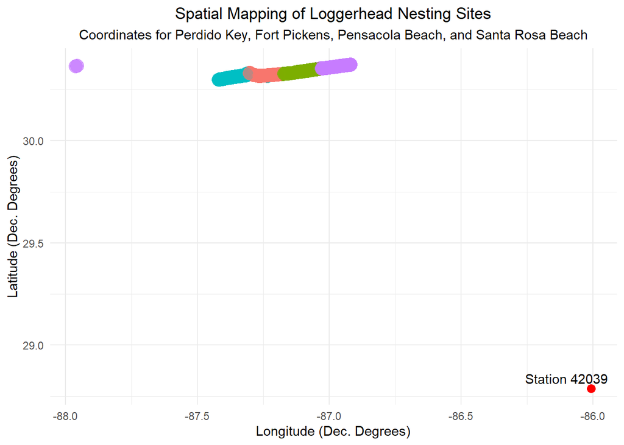

Figure 1: Spatial Mapping Of Loggerhead Nesting Sites including Station 42039 Buoy Location

## 2.3 Mathematical and Statistical Modelling

Overall, Time Series Analysis is a layered methodology where each layer can strengthen the fit and forecast of the overall model. The main steps of the analysis include:

- Exploratory Data Analysis and Visualizations
- Stationarity of Data
- Decomposition Determination
- Model Selection
- Training and Validation
- Metrics
- Forecasting and Residual Analysis

### 2.3.1 Exploratory Data Analysis and Visualizations

The first series of analysis involves

- making sure the that the points are in time order and occurs at a consistent frequency
- looking for patterns in the data and how the data changes over time
- interpreting whether it contains a Trend or any Seasonality.

At this point, we also need to identify outliers and if they are significant for the overall analysis or whether they should be trimmed. It is also important to find any data that could be interpreted as “not applicable” which would also skew the analysis with erroneous results, for example, some data points may have “n/a”, “na”, or a blank/missing value while others may put a number or letter sequence that would not match with the rest of the data.

These errors in the data may not be discovered until plotting results. Checking for linear relationships between two columns at a time may reveal mistakes in the data set or erroneous values. I was able to determine that several pairs of longitude and latitude points were incorrectly recorded based on a simple spatial mapping plot of longitude vs latitude. Since this is a collaborative effort with Dr. Schmutz (Professor of Earth and Environmental Science, UWF), he was notified so that he could make the decision to omit the data or correct it; negative signs were missing from the longitude data and he decided to correct them. We found that all erroneous temperature readings recorded from the buoy were the number ‘999’ and so this had to be filtered out too because the data would definitely be skewed.

### 2.3.2 Stationarity of Data

3 rules for strict stationarity…

Constant Mean - an upward or downward trend denotes that the series is not stationary.

Constant Variance - the volatility of the spread of the data should stay consistent over the series. Increased deviations (fluctuations) from the average as the series progresses shows non-stationarity.

Constant Autocorrelation - looking at time t and t-1 and the how they differ; the difference of the internal structure/statistical properties of the data should be constant and not significantly change over time.

The Augmented Dickey-Fuller (ADF) Test shows whether the data is Stationary based on a resulting p-value. A Time Series Plot will confirm the p-value of the ADF.

### 2.3.3 Decomposition Determination

Classical Decomposition Methods comprise of the Additive method and the Multiplicative method.

For additive decomposition, the magnitude of the seasonal fluctuations (or variation about the trend) are not expected to vary with the level of the time series as the data grows, or shrinks, over time. Essentially, we are assuming that there will be a constant absolute magnitude about which there will be seasonal fluctuations.

An additive model’s graphical representation will show that there will be parallel peaks and troughs with a consistently even width between them, respectively, even though the overall graph may be showing a positive or negative correlation.

The components (S,T,R) are proven to be independent by performing an additive decomposition and checking to see how R performs - if R (remainder/noise) remains fairly consistent, then an additive decomposition is needed; however, if R oscillates and increases in magnitude (and continues to do so) then the multiplicative decomposition has to be used.

$$y_t = S_t + T_t + R_t$$
where S=Seasonal, T=Trend, R=Residuals/Noise at time *t*

The multiplicative decomposition is used when the the magnitude of the seasonal fluctuations are proportional to the level of the time series. Essentially, there is a percentage change between the start and the end of each season and, as aforementioned, the residuals are checked for continually increasing oscillations.

$$y_t = S_t \times T_t \times R_t$$
The STL method in R - Seasonal-Trend decomposition using Loess (Locally Estimated Scatterplot Smoothing) to show the breakdown of S, T and R.

The Trend Strength, $F_t$, is the comparison of Remainder ($R_t$) versus the variance of the Data-without-Trend ($T_t + R_t$) and how much data volatility there is in the long term.
$$F_m = max(0,1-[Var(R_t)/Var(m_t + R_t)])$$
The Seasonal Strength, $F_s$, is the comparison of Remainder ($Y_t$) versus the reduction in variance of the Seasonally-Adjusted data ($S_t + R_t$) after the Trend has been removed.
$$F_s = max(0,1-[Var(R_t)/Var(s_t + R_t)])$$

### 2.3.4 Model Selection

- SARIMAX (Seasonal Autoregressive Integrated Moving Average with an Exogenous Variable) is a comprehensive time series analysis that is a combination of seasonality, autoregression, differencing, moving average and is also a forecasting method that is well suited to a biological analysis. It is an extension of the ARIMA framework that incorporates the annual seasonality of biological data and the exogenous variable of water temperature. Also, like ARIMA, SARIMAX analysis data has to be proven stationary by testing its mean and variance to ensure that future predictions are based solidly on historical pattern recognition.
  - The S (Seasonal) Component represents the **regular intervals** at which a relationship can be identified and is to be expected using biological data, i.e., finding the natural rythmn of the model.
  - The AR (Autoregressive) Component, p, involves the model using the relationship of the variable with its own **previous values** (or lagged observations).
  - The I (Integrated) Component, d, helps to **stabilize the mean** and remove trends from the time series analysis and makes it stationary by differencing (d).
  - The MA (Moving Average) Component, q, represents the effect of **previous error** terms on the present value of the time series.
  - The X (eXogenous) Component is an **external variable** that can help fill in the gaps of past behaviour of the data to soften fluctuations and strengthen future predictions. For this analysis, our exogenous variable is the Gulf of Mexico Surface Water Temperature.
  - The SARIMAX model is mathematically represented using a Backshift (B) notation where $By_t=y_{t-1}$:

$$\Phi_P(B^s)\phi_p(B)\nabla^d\nabla_s^Dy_t=\beta x_t+\Theta_Q (B^s)\theta_q(B)\epsilon_t$$

**-** $y_t$: Dependent Variable, total nesting count

**-** $x_t$: Exogenous Variable, surface water temperature

**-** $\beta$: Coefficient, quantifies impact of water temperature on nesting activity

**-** $\nabla^d$ **and** $\nabla_s^D$: Differencing Operators

**-** $\phi_p$ **and** $\Phi_P$: AR(p) and SAR(P) Components

**-** $\theta_q$ **and** $\Theta_Q$: MA(q) and SMA(Q) Components

**-** $\epsilon_t$: White Noise (error term)

- **Box-Jenkins time series method** has three steps that the time series analysis can be run through iteratively.
  - **Step 1: Identification** determines the order of the Seasonal and non-seasonal AR, I and MA components that are appropriate for the time series and where the eXogenous variable is incorporated. Within this step, there is a Stationarity Check for stability using the mean and variance of the model and this includes determining the Seasonal Stationarity. If there are significant fluntuations in the Mean (from analyzing the peaks and troughs), Seasonal Differencing(D) is needed as well as Standard Differencing (d). Next, the Autocorrelation and Partial Autocorrelation Analysis (ACF and PACF) plots are generated to identify model lags or Seasonal Spikes (most probably a multiple of 12). The spikes will be used to identify the Seasonal Autoregressive (P) and Seasonal Moving Average (Q). The Seasonality Check of the data is to confirm that there is a repeating 12-month pattern, or biological cycle where s=12, thus, validating the “S” component in SARIMAX. The relationship between the Exogenous Variable (X) and the time series nedds to be identified appropriately such that it is statistically relavent and aligned (may have to impose a lag) to the overall model and can help explain the model’s behaviour.
  - **Step 2: Estimation** is where the a model is selected based on the identified seasonal and non-seasonal parameters $(p, d, q)$ x $(P,D,Q)_s$. The AR and MA lags are also selected based on the ACF and PACF found in the previous identification step. The non-seasonal AR ($\phi$) and MA coefficients ($\theta$) will be designated as well as the seasonal AR ($\Phi$) and MA ($\Theta$) coefficients, if they exist. Lastly, for this step, the SARIMAX model’s exogenous variable coefficient ($\beta$) can be estimated. All of these parameters will be applied and the model generates the fitted values to synthesize its unique historical behavior and predictive nature while amalgamating its historic patterns with the exogenous temperature data. The Akaike Information Criterion (AIC) will be used to make a parsimonious model to ensure accuracy using as few parameters as possible - too many parameters can diminish the model’s optimization.
  - **Step 3: Diagnostic Checking** involves investigating the residuals (the difference between the predicted SARIMAX values and observed data) to ensure no additional patterns are left in the error/residual terms; the residuals should resemble “white noise” randomness. Next, the **Ljung-Box Test** is utilized to check to see if the residuals are as desired, i.e., random, followed by a mean and variance check; the desired outcome is that the residuals have a mean close to zero and a variance that is constant (homoskedasticity) confirming that the residuals do not grow or shrink over time. Also, the residuals are compared to the water temperature data to make sure that they do not correlate; if this is the case, its coefficient will have to be re-estimated. Finally, the term Iterative Refinement is used to describe the process for going back through the steps so far if the previous checks raised any issues.
- An **ACF Plot** will be generated to show the relationships within the data with respect to Seasonality and Non-stationary Trends. We will also be observing the prominence and regularity of the plot’s spikes, if the mean is shifting over time by analyzing the correlation between data and lags, and whether Differencing is required to achieve stationarity.
- A **PACF Plot** will be generated to determine the order of the standard AR (p) and the seasonal AR (P) via a “cut-off” point. A lag number will automatically be assigned for the SARIMAX model and the cut-off point should match this. This number is predicted to be 12 since we are looking at biological data. Therefore, we will be paying attention to whether the cut-off at the beginning of the plot is 12 which can lead to P being initially assigned a 1.
- The automatic base model for ARIMA that is used during programming is of the format:
  $$ARIMA(p,d,q)(P,D,Q)_{Lag}$$
  but is written within the report as:
  $$SARIMAX(p,d,q)(P,D,Q)_{Lag}$$

### 2.3.5 Training and Validation

- Based on my research, SARIMAX, Fourier series, and Prophet all handle non-linear, highly seasonal data well. “Neigbouring” of the SARIMAX model will be used to make sure that a slight adjustment will not provide a better model.
  - **SARIMAX** uses lags to its advantage and assumes high correlation with the previous 12-month instance to its current observation. It utilizes the Seasonal Moving Average or Seasonal Autoregressive terms by “remembering” historical biological patterns and distinguishing between a surge or an anomaly by taking full advantage of the environmental influence, i.e., the exogenous variable, of water temperature.
  - **Fourier Series** is used in combination with ARIMA to create a Dynamic Harmonic Regression model. The Dynamic attribute uses ARMA to handle errors or “memory” in the data. The harmonic attribute explains how it is an approximation model that breaks down the data into the sum of sine and cosine functions to handle the seasonality component to aid in mapping a predictable cycle. The Regression attribute refers to the exogenous data and handles piece-wise shifts in nesting activities. The Fourier Series allows for a relaxed approach to defining biological seasonal cycles and is an excellent choice for biological data.
  - **“Prophet”** was designed by the Data Science Team at Meta to handle fluctuations of business and biological data within time series analysis. Prophet decomposes the time series model using a Generalized Additive Model, or GAM, y(t) by Trend, g(t), Seasonality, s(t), Holidays/Events (e.g, Environmental Disasters), h(t), and an Error term, $\epsilon_t$ - $ y(t)=g(t)+s(t)+h(t)+_t $ - it then looks at the series and adjusts curves to show the relationship rather than analyzing the actual relationship between the data points. Prophet is known to handle missing data, more resilient to outliers, and extra exogenous variables can be added. It also incorporates the Fourier Series for the Seasonal aspect to generate a smoothed seasonal cycle.
  - **“Neighboring”**, or Stepwise Evaluation of Neighboring Parameters, can be used as a comparison to validate the correctness of the chosen model, e.g., changing p=0 (no immediate memory) to p=1 (1 month memory). Depending on what the SARIMAX model is, I will research what its “neighbor” should be and then test to make sure it is not better than the chosen model. There is also a balance to maintain between the simplicity and the accuracy of the model - one make the model as parsimonious as possible with the fewest number of parameters whilst maintaining accuracy.
- **Note:** Exponential Smoothing was considered but upon further research, it was not a good candidate because it can not handle the exogenous data well although it can generally handle outliers better than SARIMAX.

### 2.3.6 Metrics

- **AIC (Akaike Information Criterion) score:** used to find the most parsimonious (efficient and simple) model from all of these methods; the lowest AIC score is usually the best but have to check the parameter count.
- **“ma” coefficients:** Moving Average coefficients are used to correct predictions from the previous point of the forecast, more likely to be a monthly forecast.
- **“sma” coefficient:** Seasonal Moving Average coefficients handles correcting predictions from the previous point of the forecast, more likely to be a yearly forecast.
- **s.e. - Standard Error** measures the reliability of ALL of the coefficients generated. As a rule, if the coefficient being compared is roughly double that of the standard error, the coefficient is deemed statistically significant corresponding to a $p-value$ of 0.05.
- **sigma2 - $\sigma^2$** is the variance of the residuals, or remaining noise, in the model that can not be explained. A lower $\sigma^2$ suggests a better, tighter fit.
- **RMSE - Root Mean Squared Error** is a measure of trust in the model’s predictions. It averages the distance between the model’s predictions against the original observed data. The RMSE will be in the same units as the data which, in our case, is number of nests.

## 2.4 Software and Tools

- R Programming Environment - widely used for time series analysis.
- fpp3 “Forecasting:Principles and Practice” meta-package.
- tsibble - creation and management of data frames.
- feasts - “Feature Extraction and Statistics for Time Series”, used for calculating the Ljung-Box p-value.
- fable - primary modeling entity for defining, estimating, and forecasting SARIMAX and Fourier ARIMA models.
- fable.prophet - to incorporate the Generalized Additive Model (GAM)
- STL method - Seasonal-Trend decomposition using Loess (Locally Estimated Scatterplot Smoothing).

## 2.5 Ethical Considerations

Data integrity and Transparency

Conservation Policies

Sensitive Information/Species Protection

# 3 Results

The analysis addresses the extent at which the nesting trends are changing with respect to:

- time
- water temperature (possible sex imbalance inference)

## 3.1 Core Findings

### 3.1.1 Exploratory Data Analysis and Visualizations

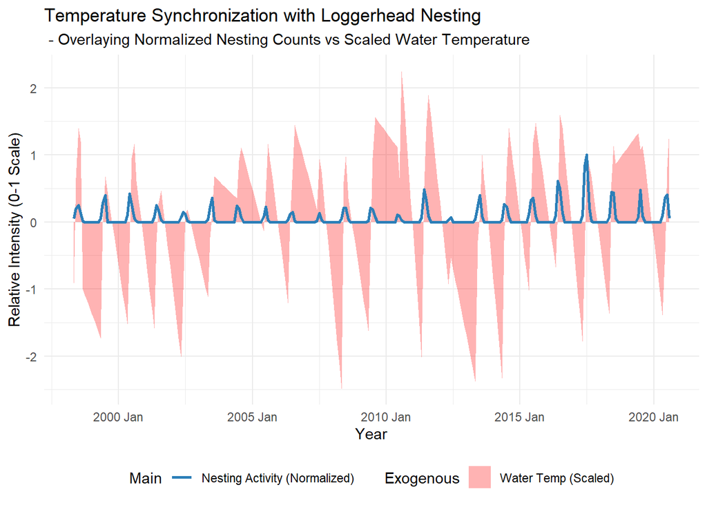

### 3.1.2 Stationarity of Data

- Null Hypothesis, $H_0$: The data is non-stationary and contains a unit root
- Alt. Hypothesis, $H_1$: The data is stationary and does not contain a unit root
- Fail to Reject the Null Hypothesis iff p > 0.05
- The Augmented Dickey-Fuller (ADF) Test Results
  - for **Nesting Activity, p = 0.0868**, and
  - for **Average Gulf Surface Temperature, p = 0.1000**.
- Conclusion: We Fail to Reject the Null Hypothesis; **both sets of data are non-stationary** and the data must be stabilized.
- A Time Series Plot was configured and it showed that the **Mean and Variance were NOT constant** due to the peaks and valleys, i.e., confirming evidence that the data is Non-Stationary.

### 3.1.3 Decomposition Determination

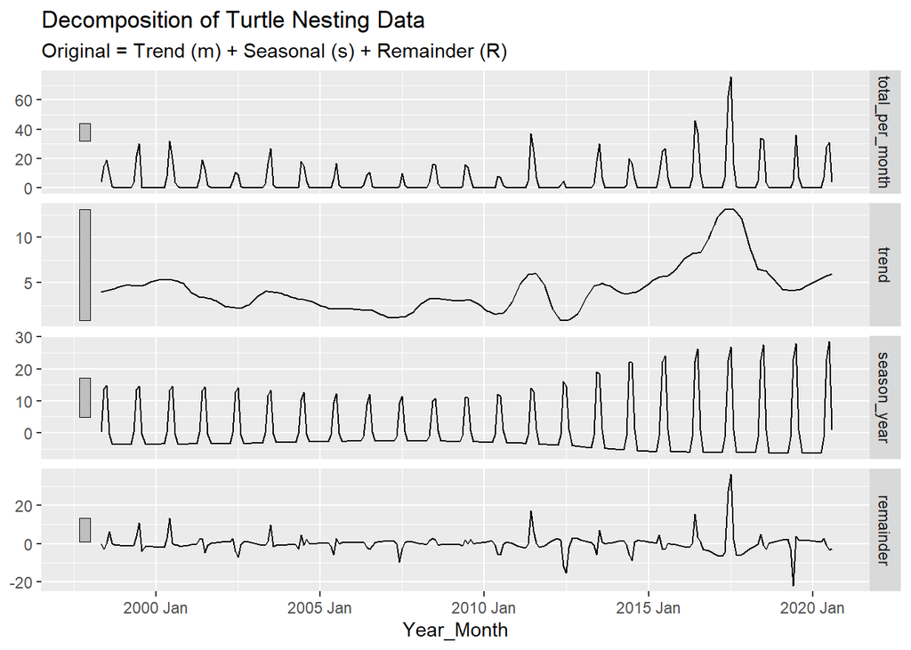

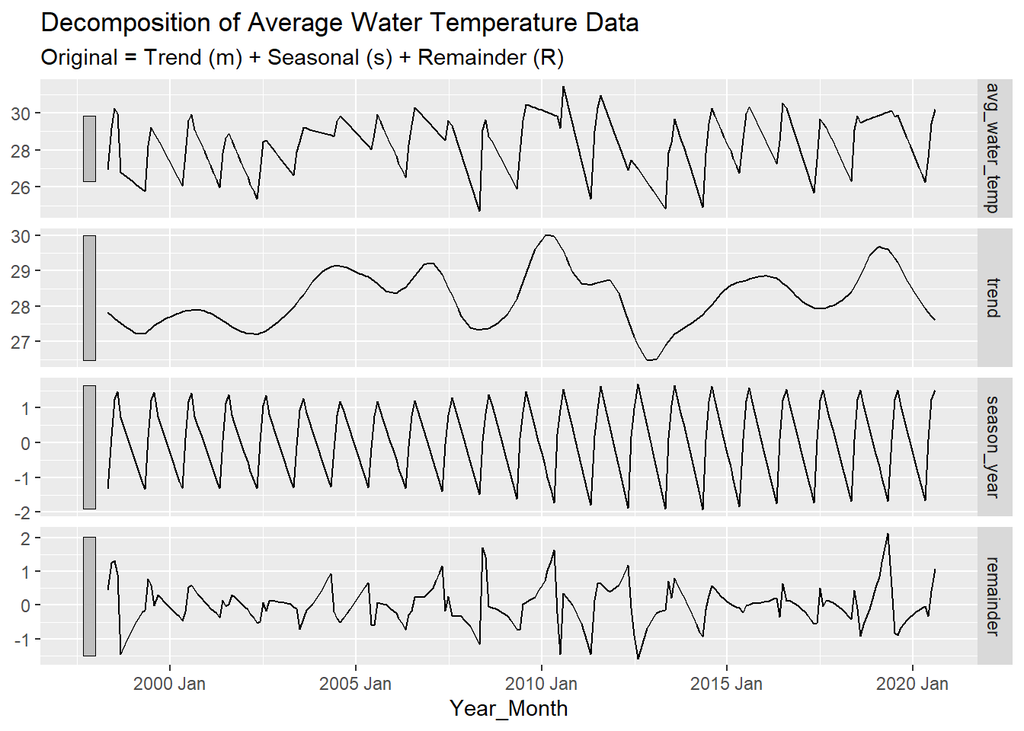

### 3.1.4 Model Selection

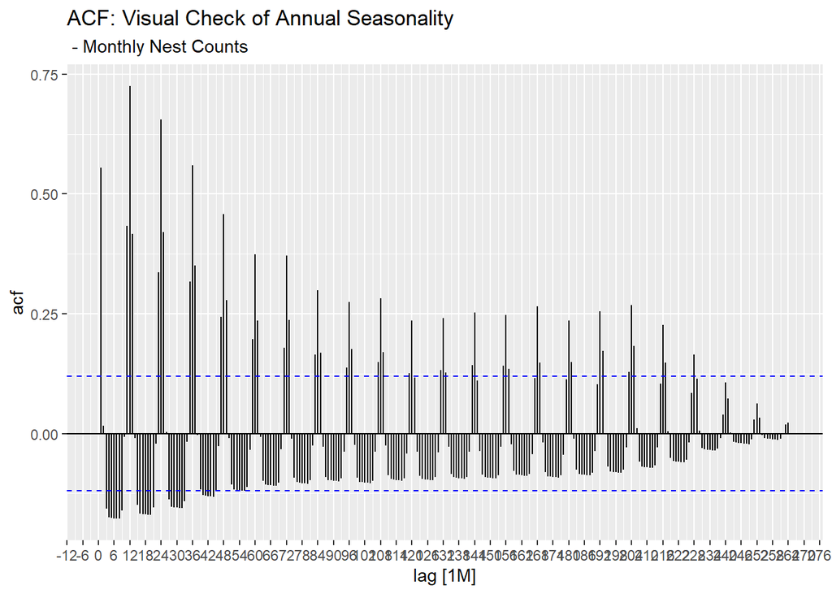

- The Nesting ACF Plot shows that there is Seasonality in the data showing yearly peaks. There is a definite trend since the bars stay high and decrease slowly over all lags. This also shows that the mean is shifting over time and Differencing is required for SARIMAX modelling.

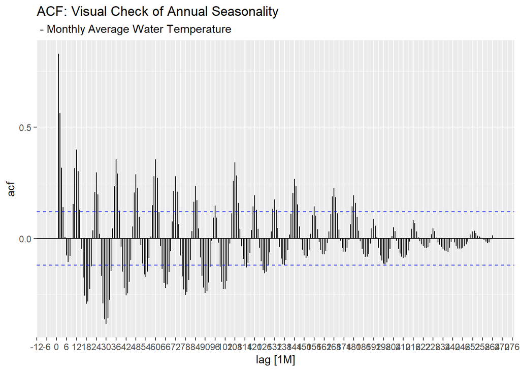

- The Water Temperature ACF Plot shows that there is Seasonality in the data showing varied yearly peaks. There is a trend since the bars generally stay high and decrease slowly over all lags with minor fluctuations. This corresponds to the mean shifting over time and supports that Differencing is required for the SARIMAX model.

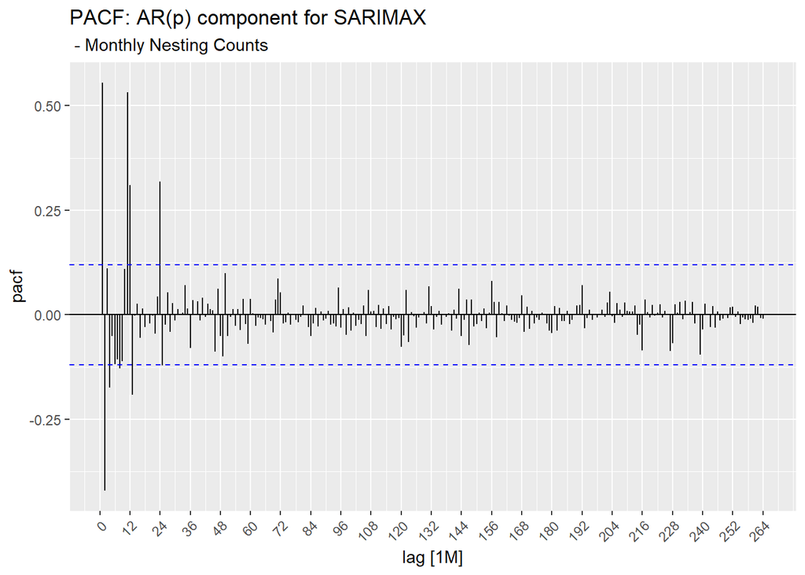

[figure not shown]

SARIMA Automatic Modelling Coefficients

- ARIMA(0,0,2)(0,0,1)[12] for Nesting Activity

| Parameter | Coefficient | Std. Error | z-value |
| --- | --- | --- | --- |
| ma1 | 0.6001480 | 0.06212687 | 9.660039 |
| ma2 | 0.1378960 | 0.06141272 | 2.245397 |
| sma1 | -0.6977397 | 0.05465797 | -12.765562 |

- The automatically-fitted model gives us ARIMA(0,0,2)(0,0,1)[12] and the backshift equation is as follows:

$$y_t=(1+\theta_1 B+ \theta_2 B^2)(1+\Theta_1 B^{12})\epsilon_t$$
- However, the ADF test shows that the model is non-stationary and is in need of Differencing. We must keep the model as parsimonious as possible but the model is invalid in its current form. Adding Differencing, D = 1, will satisfy the requirement to stabilize the data and, also, flatten out the mean over time. This model will be tested as a “neighbor” model during training and validation stage to verify its fit. Adding the Differencing adds a term to the left side of the model equation and mathematically interprets the annual changes in turtle nesting as shown below:
$$(1-B^{12})y_t=(1+\theta_1 B+ \theta_2 B^2)(1+\Theta_1 B^{12})\epsilon_t
=(1+0.6B+ 0.14B^2)(1-0.7B^{12})\epsilon_t$$

**-** ma1 = 0.60 (s.e. = 0.063, significant since ma1 > 2*se)

**-** ma2 = 0.14 (s.e. = 0.062, significant since ma2 > 2*se)

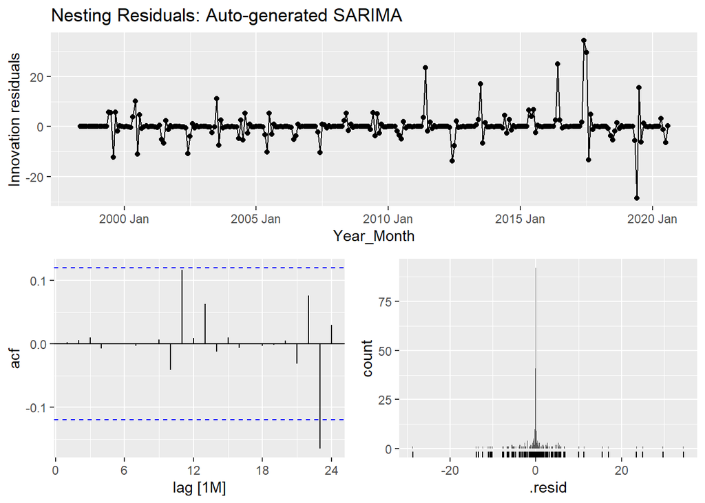

- The ARMA, or Autoregression (AR) and Moving Average (MA), base accounts for zero AR terms and a two month MA. The AR is zero because of the strong seasonality of the model (PQ has more influence). Also, the exogenous surface water temperature shows that it holds the momentum of the monthly nesting activity and provides an innate seasonality to the model.
- The S in SARIMA includes Seasonality to the ARIMA model; P, D, and Q define the Seasonality of the model as well as the Differencing needed to stabilize the mean.
- The X in SARIMAX adds the exogenous (external) variable of Surface Water Temperature and also adds an environmental influence.
- The final SARIMAX equation with respect to Nesting Activity, and including Differencing, is as follows:

$$SARIMAX(p,d,q)(P,D,Q)_{AnnualLag} = SARIMAX(0,0,2)(0,1,1)_{12}$$

- Difference: **d = 0**, although the mean was not a flat horizontal line, it was stable across of the series. Adding d = 1 makes the model less parsimonious, therefore less efficient, and avoids over-differencing which almost always leads to overfitting.
- Seasonal Difference: **D = 1**, due to strong Seasonal Strength of both the nesting activity and the water temperature, the model is strong enough to drive its own seasonality; it could also be that the dip in 2019 nesting activity could have been the slight disruption that set D = 0.
- Autoaggressive: **p = 0**, the number of nests found in one month does not have a ripple effect from the previous month possibly because turtles nest up to every two weeks (on average) during a season but only make an average of 4 nests over a maximum season of 5 months.
- Seasonal Autoaggressive: **P = 0**, the number of nests found in one season does not have a ripple effect from the previous season possibly because turtles nest every two or more years (on average).
- Moving Average: **q = 2**, the model has memory from the previous 2 months to adjust for the current month.
- Seasonal Moving Average: **Q = 1**, the model is able to adjust for inconsistencies in nest counts from last year to the current year’s prediction. Inconsistencies can arise from weather deviations like cold snaps or hurricanes and other environmental disasters like the Gulf oil spill of Summer, 2010.
- Checking Residuals: shows the graphical representation of the residuals. The following analysis proves that the Auto-generated ARIMA can be considered an accurate representation of the model.
  - The Innovation Residuals show that the minor “shock” fluctuations mostly remain around a zero-mean like ideal “White Noise”. The unexpected negative influence (significant innovation or “shock”) at the end of the system shows that the model was not expecting the lower nesting numbers. The equation below explains how the “shocks” that occur in the system are represented to account for unpredictable fluctuations after seasonal and trend instances have been accounted for.

$$\epsilon_t = y_t - E[y_t|PastInformation]$$

### 3.1.5 Training and Validation

Models AICc Scores (Ranked Lowest to Highest)

| Model | AIC | AICc | BIC | Log Likelihood | Sigma Squ. |
| --- | --- | --- | --- | --- | --- |
| n_sarimax_002_011 | 1437.11 | 1437.28 | 1450.96 | -714.55 | 24.62 |
| temp_sarimax_002_011 | 1438.26 | 1438.52 | 1455.58 | -714.13 | 24.63 |
| auto_sarimax | 1438.75 | 1439.25 | 1463.00 | -712.38 | 24.49 |
| temp_sarimax | 1440.17 | 1440.80 | 1467.88 | -712.08 | 24.53 |
| fourier_sarimax_5 | 1500.54 | 1502.90 | 1556.76 | -734.27 | 23.02 |
| fourier_sarimax_6 | 1502.54 | 1505.20 | 1562.27 | -734.27 | 23.12 |
| fourier_sarimax_4 | 1504.21 | 1506.01 | 1553.40 | -738.11 | 23.51 |
| fourier_sarimax_3 | 1518.99 | 1520.32 | 1561.15 | -747.50 | 25.05 |
| fourier_sarimax_2 | 1539.44 | 1540.37 | 1574.57 | -759.72 | 27.28 |
| temp_sarimax_002_001 | 1625.56 | 1625.91 | 1646.64 | -806.78 | 39.55 |
| sarimax_002_001 | 1631.76 | 1632.01 | 1649.33 | -810.88 | 40.69 |
| gam_fourier_4 | 1636.81 | 1637.73 | 1671.94 | -808.40 | 41.20 |
| ets_model | 2262.00 | 2264.07 | 2314.71 | -1116.00 | 34.63 |
| base_snaive | NA | NA | NA | NA | 49.45 |

### 3.1.6 Forecasting

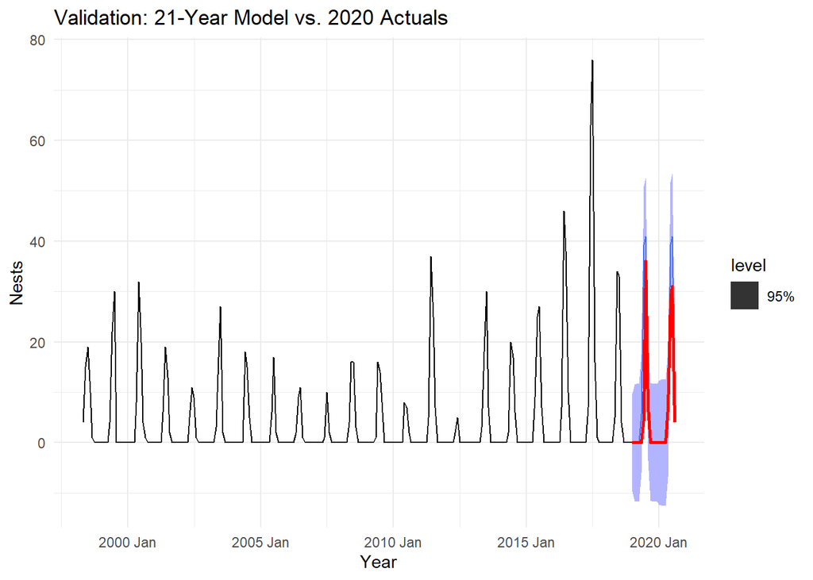

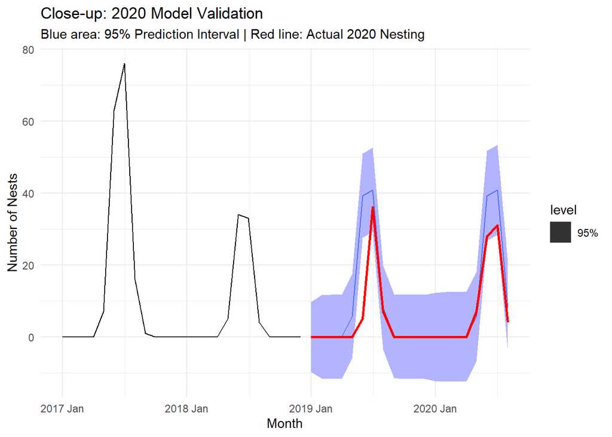

### 3.1.7 Metrics

Ljung-Box Residual Test Results

- n_sarimax_002_011

| Model | Q-Statistic | p-value |
| --- | --- | --- |
| n_sarimax_002_011 | 10.63584 | 0.9694178 |

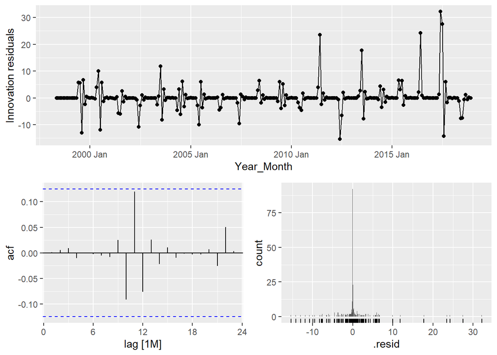

- Only 3 parameters (degrees of freedom) used: q=2 (ma1, ma2) and D=1, Q=1, (sma1).
- With greater than 0 parameters used, the independence from the residuals is confirmed and the model is not over-fitted.
- The p_value is greater than 0.05, we fail to reject the Null Hypothesis which mathematically proves that the residuals are White Noise.
- After applying the Ljung-Box test have officially passed the “base_sarimax”.
  $$dof = TotalLags-(p+q+P+Q)=24-3=21$$

Root Mean Squared Error & Mean Average Error

- n_sarimax_002_011

| Model | RMSE | MAE |
| --- | --- | --- |
| n_sarimax_002_011 | 8.578671 | 3.636515 |

## 3.2 Model Performance and Comparisons

$$y_t=\beta(Temperature_t) +\eta_t$$
where $\eta_t$ is an ARIMA process

## 3.3 Uncertainty and Variability

# 4 Discussion

## 4.2 Limitations and Challenges

No new data after 2020 available.

## 4.3 Implications

The unbiased nature of the model is very important when used with respect to conservation efforts. Since the residuals are centered about zero, the model can estimate the population fairly accurately without over- or under-estimating. This provides a realistic baseline for the nesting activity of the Loggerhead Turtles resulting in informed protection efforts and more precise resource allocation along the Gulf Coast.

# 5 Conclusion

## 5.2 Future Work

Top 5 Models AICc Scores (Ranked)

- Complete Dataset, 1998-2020

| Model | AIC | AICc | BIC | Log Likelihood | Sigma Squ. |
| --- | --- | --- | --- | --- | --- |
| auto_full | 1588.06 | 1588.22 | 1602.24 | -790.03 | 27.48 |
| neighbor_full_1 | 1588.06 | 1588.22 | 1602.24 | -790.03 | 27.48 |
| temp_full | 1589.79 | 1590.03 | 1607.52 | -789.90 | 27.55 |
| temp_full_1 | 1589.79 | 1590.03 | 1607.52 | -789.90 | 27.55 |
| f100_sarimax_5 | 1642.51 | 1644.68 | 1699.97 | -805.26 | 25.09 |

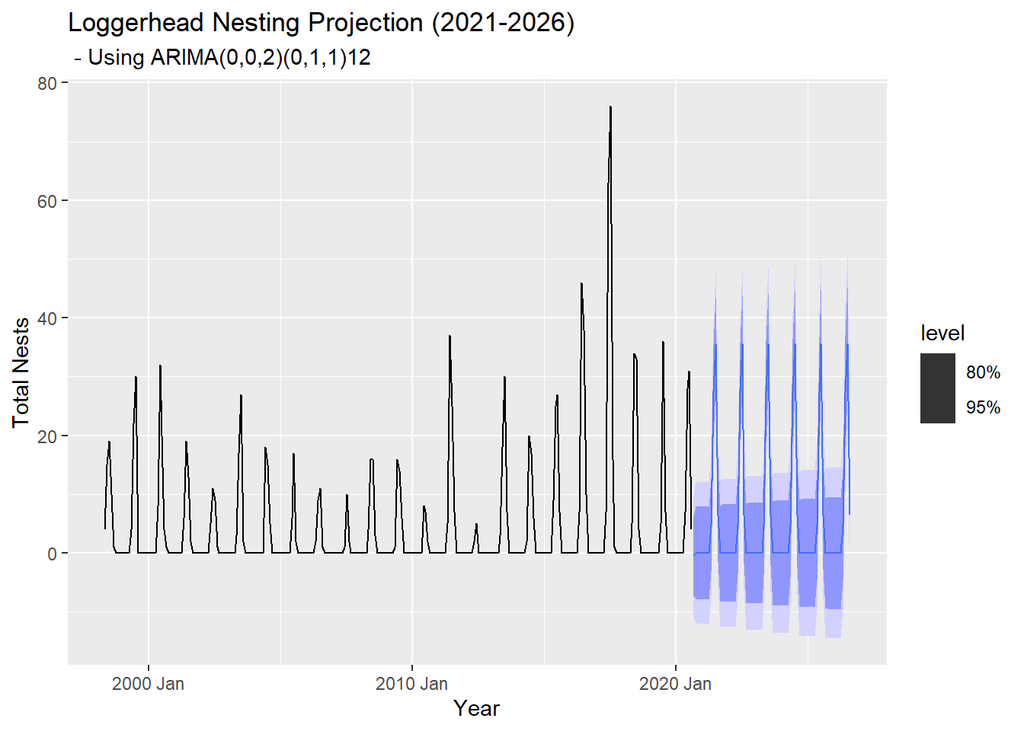

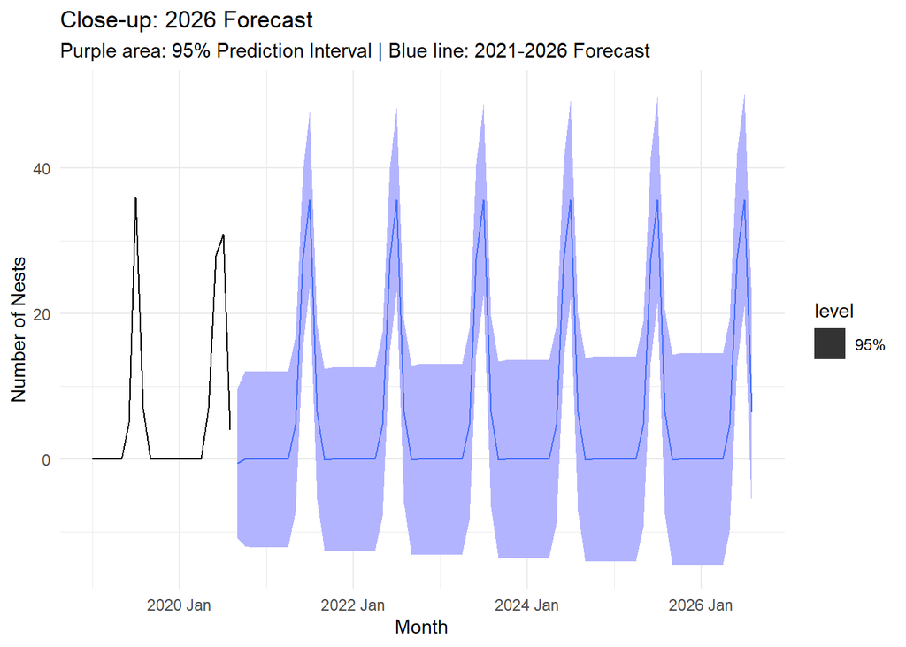

## 5.3 Additional Visualization and Tables

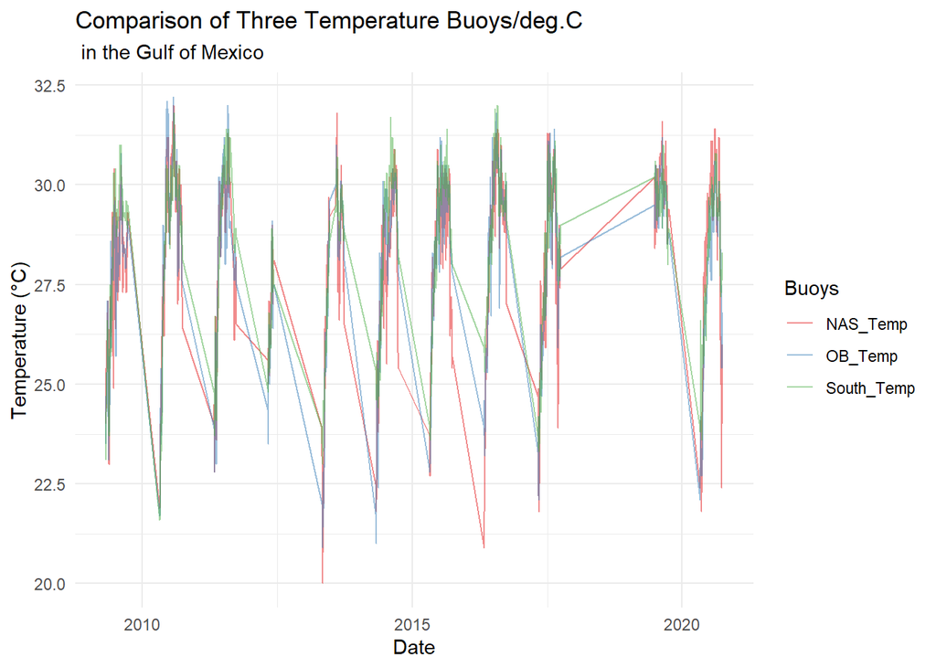

Figure 2: Comparison of Three Temperature Buoys/deg.C

Table 2: Tukey HSD Comparison of Mean Water Temperatures

| Comparison | Difference (degC) | Lower Bound | Upper Bound | p-adj |
| --- | --- | --- | --- | --- |
| OB_Temp-NAS_Temp | -0.0131 | -0.2010 | 0.1748 | 0.9854 |
| South_Temp-NAS_Temp | 0.2141 | 0.0262 | 0.4020 | 0.0207 |
| South_Temp-OB_Temp | 0.2272 | 0.0393 | 0.4151 | 0.0128 |

[output not shown]

[output not shown]

[output not shown]

[output not shown]

[output not shown]

[output not shown]

[output not shown]

[output not shown]

[output not shown]

[output cut: 167 more lines]

[output not shown]

Table 3: Nesting Data with Scaled Temperature Table (Partial)

Nesting Data with Scaled Temperature for Plotting Purposes (Partial)

| Year | Total Nests | Avg Water Temp. | Scaled Temp. |
| --- | --- | --- | --- |
| 1998 May | 4 | 26.92500 | -0.9128737 |
| 1998 Jun | 15 | 29.17333 | 0.6594344 |
| 1998 Jul | 19 | 30.23684 | 1.4031690 |
| 1998 Aug | 10 | 29.95000 | 1.2025741 |
| 1998 Sep | 1 | 26.80000 | -1.0002889 |

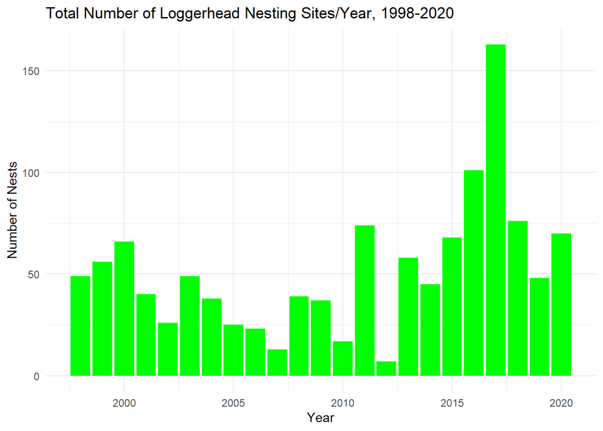

Figure 3: Total Number of Loggerheads Nesting Sites/Year, 1998-2020

Beach Area Nest Totals

| Location | Nest Total |
| --- | --- |
| Perdido Key | 366 |
| Santa Rosa Beach | 301 |
| Pensacola Beach | 278 |
| Fort Pickens | 243 |

Figure 4: Area Totals of Loggerhead Turtle Nesting Sites: 1998-2020

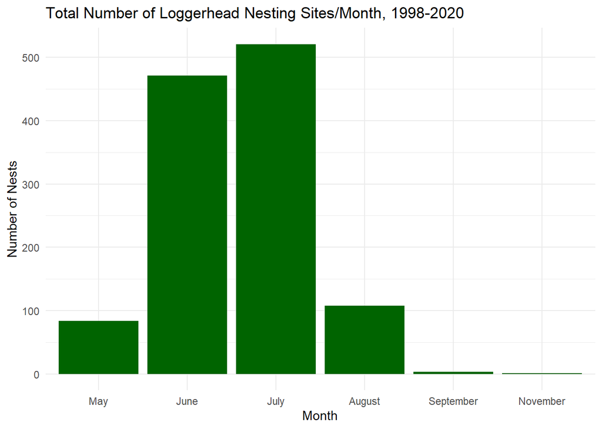

Figure 5: Total Number of Loggerhead Nesting Sites/Month, 1998-2020

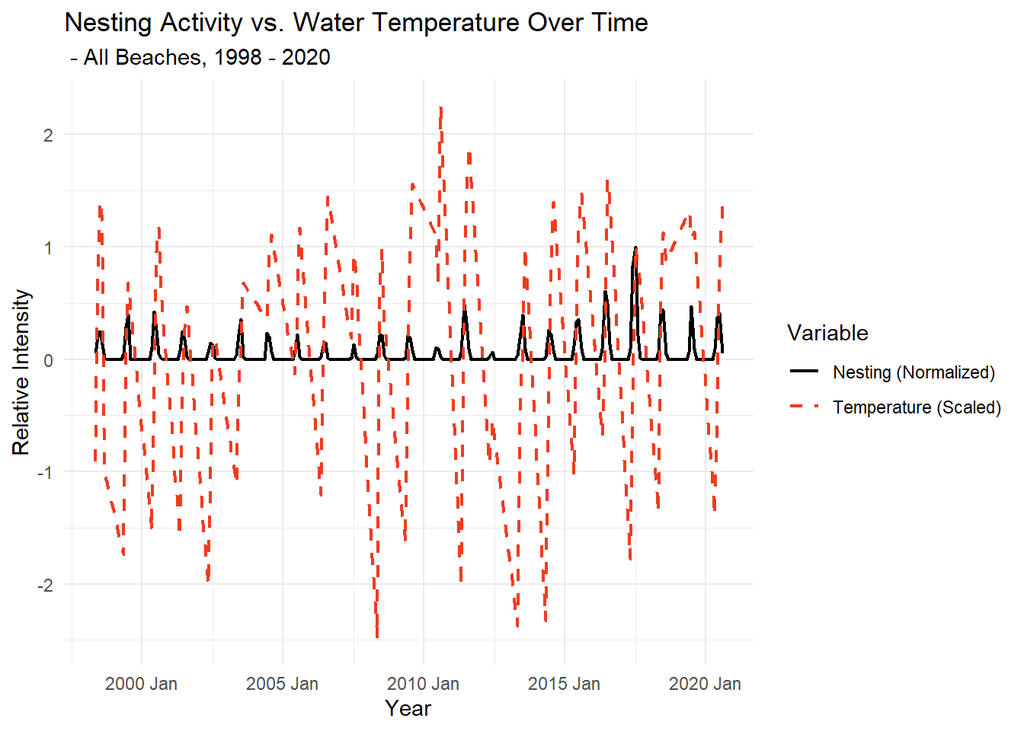

Annual Loggerhead Nesting Season Dates

- 1998-2020, Gulf Coast Study Area

| Year | Start Date | End Date | Total Sites |
| --- | --- | --- | --- |
| 1998 | 1998-05-23 | 1998-09-06 | 49 |
| 1999 | 1999-05-24 | 1999-07-20 | 56 |
| 2000 | 2000-05-09 | 2000-09-22 | 65 |
| 2001 | 2001-05-27 | 2001-08-12 | 40 |
| 2002 | 2002-05-03 | 2002-08-12 | 26 |
| 2003 | 2003-05-21 | 2003-08-04 | 49 |
| 2004 | 2004-06-08 | 2004-08-18 | 38 |
| 2005 | 2005-06-04 | 2005-08-11 | 25 |
| 2006 | 2006-05-25 | 2006-08-07 | 23 |
| 2007 | 2007-06-27 | 2007-08-06 | 13 |
| 2008 | 2008-05-21 | 2008-08-20 | 39 |
| 2009 | 2009-05-18 | 2009-08-21 | 37 |
| 2010 | 2010-06-07 | 2010-08-05 | 17 |
| 2011 | 2011-05-19 | 2011-08-21 | 74 |
| 2012 | 2012-05-23 | 2012-06-07 | 7 |
| 2013 | 2013-05-11 | 2013-08-14 | 58 |
| 2014 | 2014-05-20 | 2014-08-30 | 45 |
| 2015 | 2015-05-13 | 2015-08-31 | 68 |
| 2016 | 2016-05-18 | 2016-08-31 | 101 |
| 2017 | 2017-05-16 | 2017-09-05 | 163 |
| 2018 | 2018-05-19 | 2018-08-11 | 76 |
| 2019 | 2019-06-28 | 2019-08-30 | 48 |
| 2020 | 2020-05-22 | 2020-08-17 | 70 |

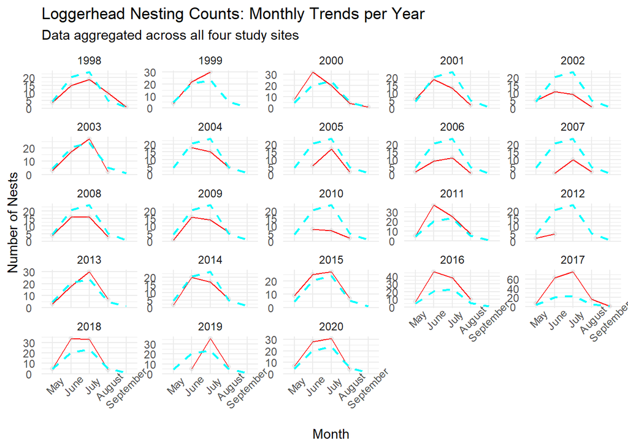

## References

Box, & Jenkins, G. E. P. 1970. *Time Series Analysis: Forecasting and Control*. San Francisco, CA: Holden-Day.

Hyndman, Rob J., and George Athanasopoulos. 2026. *Forecasting: Principles and Practice*. https://otexts.com/fpp3/https://otexts.com/fpp3/.

MathWorks. 2026. “Time Series Analysis.” 2026. https://www.mathworks.com/discovery/time-series-analysis.html.

Mazaris, Matsinos, Kornaraki. 2004. “Modeling the Effect of Sea Surface Temperature on Sea Turtle Nesting Activities by Investigating Seasonal Trends.” *Natural Recourse Modeling*.